# Project 1

Michael Rees - SDS 313 UT Austin

2024-09-27

# **1. Introduction**

This dataset of the greatest albums of all time is a list compiled by [The Rolling Stones](https://rollingstones.com/) a website covering music. To compile the list, the Rolling Stones polled artists, songwriters, producers, A&Rs, executives, and their staff to make this list. This list was also compiled in 2003 and 2012, along with the dataset in use, the information gathered for 2020. It gives information on the artist, album name, genre, release year, type of album, time and peak on the billboard, spotify popularity, and the amount of artists on the album.

[figure not shown]

*Album Cover for Dark Side of the Moon, by Pink Floyd. Source: [Wikipedia](https://en.wikipedia.org/wiki/The_Dark_Side_of_the_Moon)*

# **2. Outcome Variable**

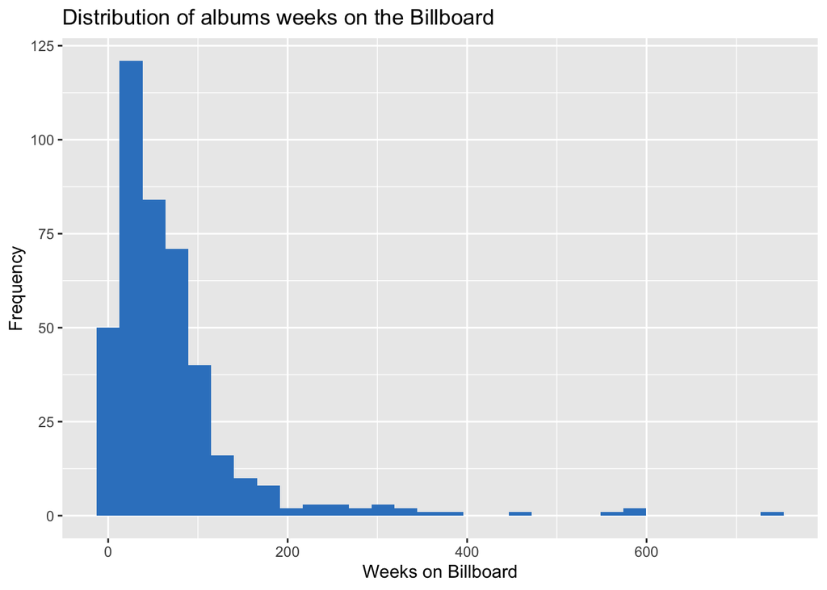

The primary variable that will be investigated is the weeks on the billboard for each of the albums in the rolling stones top 500 ranking. The distribution for this variable is skewed right with a median of 51 and a mean of 70.26.

# **3. Bivariate Analyses**

### **Weeks on Billboard and Genre**

[figure not shown]

As can be seen in this distribution, ignoring outliers, the distribution of weeks on the billboard does not differ largely between the genres shown above. Soul, Gospel, and R&B have the highest upper outlier, but the median amount of time on the billboard is 58, not the highest of the 5 genres shown above. Indie and Alternative Rock have the highest median at 75 but have the second lowest upper outlier.

### **Peak Billboard Position of Albums**

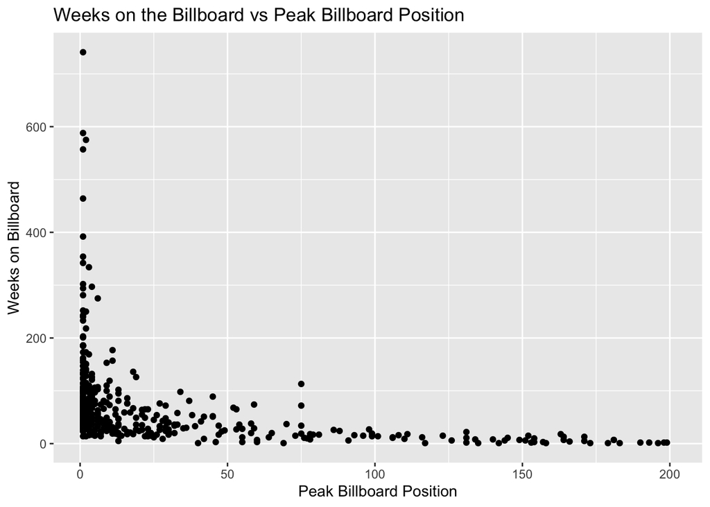

Since this list is composed of the best albums of all time, it can be expected that a significant portion of these albums have been place at #1 on the billboard at some point in time. This leads this graph to have a large stack of datapoints at the #1 peak position, and then quickly trailing off to the albums that did not peak as high on the billboard. This essentially exponential connection caused by the bias in this dataset can be seen in the week correlation between these two variables, -0.38.

### **Spotify Popularity of Albums**

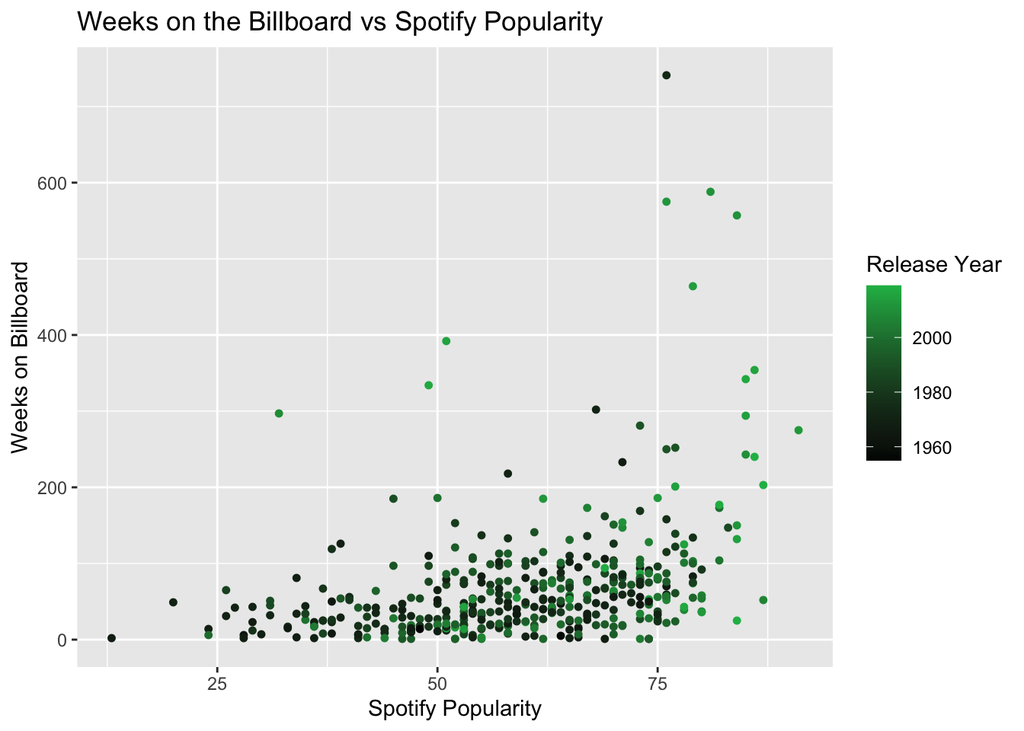

The correlation between weeks on the billboard and spotify popularity is not very strong with correlation of 0.41, but it is clearly shown by the graph that there is some connection with albums with more weeks on the billboard generally having more spotify popularity. The prime example of this is the [Dark Side of the Moon](https://open.spotify.com/album/4LH4d3cOWNNsVw41Gqt2kv) an album by Pink Floyd, which has by far the most weeks on the billboard while being one of the most popular albums on spotify. Even with this example, these variables might not correlate as much as one might expect due to the medium some of the albums in the top 500 ranking. As can be seen by the release year, the albums with more recent release years are much more likely to appear higher in the spotify popularity since more recent albums are much more likely to released and promoted on streaming services such as spotify. Despite this, they do no have much correlation directly with the weeks on the billboard as can be seen by the correlation coefficient 0.34.

# **4. Conclusion**

### **References**

“The Dark Side of the Moon.” Wikipedia, en.wikipedia.org/wiki/The_Dark_Side_of_the_Moon. Accessed 25 Sept. 2024.

“The Dark Side of the Moon.” Spotify, open.spotify.com/album/4LH4d3cOWNNsVw41Gqt2kv.

Rfordatascience. “Tidytuesday/Data/2024/2024-05-07/readme.md at Master · Rfordatascience/Tidytuesday.” GitHub, 7 May 2024, github.com/rfordatascience/tidytuesday/blob/master/data/2024/2024-05-07/readme.md.

Riva, Matt Daniels Chris Dalla. “What Makes an Album the Greatest of All Time?” The Pudding, pudding.cool/2024/03/greatest-music.

“The Rolling Stones | Official Website.” The Rolling Stones | Official Website, 23 Feb. 2024, rollingstones.com.